# Local uncertainty

Oskar Randen

20 mai 2019

### Load packages

```r
library(httr) # GET, content
library(tidyverse)
library(stringdist)
library(reshape2)
library(jsonlite)
library(pxweb) # Statistics Norway API
library(zoo) # Linear approximation
```

## Norwegian national library

The Norwegian national library is digitizing its newspaper collection. This is an ongoing process, which means that a lot of data is still missing. Still, there is partial data from 400 newspapers from 1763 until today.

### Wildcard search

A wildcard search is a search that matches every string that starts with any of the strings provided. I do a wildcard search in the database using the Norwegian words for **uncertainty**.

Uncertainty words = “usikkerhet”, “uvisse”, “uvissa”

```r
rm(list = ls())

startYear <- 2000
endYear <- 2013
noYears <- endYear - startYear + 1

# factor: by how many positions wildcards are expanded
# limit:  top #limit results,
# freq_lim: discard results with less than #freq_lim hits
unc_words <- c("usikkerhet*", "uvisse*", "uvissa*")
key_list <- c()

for (i in seq_along(unc_words)) {
querylist =
  list(
    word = unc_words[i],
    corpus = "avis",
    factor = "20",
    limit = "1000",
    freq_lim = "2"
  )
query_result = GET(url = "https://api.nb.no/ngram/wildcards", query = querylist)
key_list = c(key_list, names(content(query_result)))
}
```

### List of uncertainty words used in the model:

There are 636 unique strings starting with **uncertainty**. This includes strings ending with punctuation such as round bracets, forward slash or question mark.

```r
sort(key_list)
```

```
##   [1] "usikkerhet"                      "usikkerhet-"
##   [3] "usikkerhet!"                     "usikkerhet!Â»"
##   [5] "usikkerhet\""                    "usikkerhet\","
##   [7] "usikkerhet)"                     "usikkerhet),"
##   [9] "usikkerhet)."                    "usikkerhet,"
##  [11] "usikkerhet,\""                   "usikkerhet,Â»"
##  [13] "usikkerhet."                     "usikkerhet.\""
##  [15] "usikkerhet..."                   "usikkerhet.Â»"
##  [17] "usikkerhet:"                     "usikkerhet;"
##  [19] "usikkerhet?"                     "usikkerhet?Â»"
##  [21] "usikkerhetÂ»"                     "usikkerhetÂ»."
##  [23] "usikkerheta"                     "usikkerhetcn"
##  [25] "usikkerhetcr"                    "usikkerhete"
##  [27] "usikkerheten"                    "usikkerheten!"
##  [29] "usikkerheten)"                   "usikkerheten,"
```

[output cut: 303 more lines]

### Wordcounts

Using the n-gram API, i count the number of uncertainty words from the wildcard search, per month, per newspaper. I also count the total number of words.

```r
key_list <- c(key_list, tools::toTitleCase(key_list))
names(key_list) <- rep("word", length(key_list))
key_list <- lapply(key_list, function(x) URLencode(x, reserved=T))
key_list <- list(total = list(total = "yes"),
                uncertainty = key_list)

# Get list of newspapers
url_nb <- "https://api.nb.no/ngram/ngram"
querylist   <- list(corpus = "avisnavn", word = "%")
papers_list <- GET(url = url_nb, query = querylist)
papers_list <- unlist(content(papers_list))

for (mth in 1:12) {

    for (paper in papers_list) {
    print(paste0(paper, " (Month: ", mth, ")"))

    main <- data.frame(year  = 2000:2018,
                      paper = paper,
                      month = mth)
    main[, names(key_list)] = 0

    for (k in 1:length(key_list)) {

      for (i in 1:length(key_list[[k]])) {

        querylist <-
          c(
            key_list[[k]][i],
            list(
              paper_name = paper,
              month = mth,
              corpus = "avis",
              yearfrom = "2000",
              yearto = "2018"
            )
          )

        out <- GET(url = url_nb, query = querylist)
        out <- unlist(content(out))

        if (is.null(out))
          next()

        newdata <- as.data.frame(t(matrix(out, nrow = 2)))
        newdata <- aggregate(newdata$V2, list(newdata$V1), FUN = sum)
        r <- newdata$Group.1 - (2000 - 1)
        c <- names(key_list[k])
        main[r, c] <- main[r, c] + newdata$x

      } # keys
    } # key_list
    dataset <- bind_rows(main, if (exists("dataset")) dataset)

  } # mth_list, papers_list

}

saveRDS(dataset, "Data/monthlyData.rds")
```

### Data cleaning

Cleaning the national library data consists of three main steps: 1. Remove non-Norwegian language newspapers. 2. Remove newspapers with only one observation. 3. Combine newspaper series. Several newspapers are registrered under more that one name in the database. (e.g Dagsavisen and Arbeiderbladet). I decided to merge these manually.

```r
database <- readRDS("Data/monthlyData.rds")
database$paper <- as.character(database$paper)
names(database)[6] <- "uncertainty"

database$paper <- as.character(database$paper)

database <- database %>% filter(!total == 0)

uniquePapers <- length(unique(database$paper))

# Remove non-Norwegian papers:
database <- database %>% filter(!paper %in% c("avvir", "upstream", "tradewinds", "recharge", "assu", "minaigi", "ruijankaiku"))

uniquePapers <- c(uniquePapers, length(unique(database$paper)))

# Combines newspapers series that contains the same paper under different names:
toReplace <- c("dagsavisen", "dagsavisen", "dagsavisen", "bergensavisen", "gudbrandsdoelendagning", "gudbrandsdoelendagning", "gudbrandsdoelendagning", "gudbrandsdoelendagning",
               "tronderavisa", "dagensnaeringsliv", "smaalenenesavis", "nytid", "samholdvelgeren", "helgelandarbeiderblad", "telemarksavisa", "budstikkaforaskerogb", "dagenmagazinet",
               "drammenstidende", "drammenstidende", "fiskeribladetfiskare", "tromsfolkeblad", "friheten", "gjengangeren", "hardangerfolkeblad", "lofotposten",
               "telemarksavisa", "eidsvollullensakerbl", "hardangerfolkeblad", "avisanordland", "avisanordland", "fiskeribladetfiskare")

toBeReplaced <- c("arbeiderbladetoslo", "arbeiderbladet", "dagsavisenarbeiderbladet", "bergensarbeiderblad", "gudbrandsdolen", "dagningen", "gudbrandsdoelen", "gudbrandsdolendagnin",
                  "nordtrondelaginntrondelagen", "norgeshandelsogsjoefartstidende", "oevresmaalenene", "orientering", "samholdgjoevik", "helgelandarbeiderbla", "telemarkarbeiderblad", "askerogbaerumsbudstikke", "dagenbergen",
                  "drammenstidendeogbuskerudblad", "drammenstidendeogbus", "fiskeribladet", "tffolkebladet", "friheten2", "gjengangeren2", "hardangerfolkeblad", "lofotposten2",
                  "telemarkarbeiderblad", "eidsvoldblad", "hardanger", "nordlandsframtid", "nordlandsposten", "fiskaren")

replacement <- data.frame(toReplace, toBeReplaced)

for (i in seq_along(toBeReplaced)) {
database[database$paper == toBeReplaced[i], 3] <- toReplace[i]
}

uniquePapers <- c(uniquePapers, length(unique(database$paper)))

# Remove papers with only one observation
oneObs <- database %>% group_by(paper) %>% count() %>% filter(n == 1)
database <- database %>% filter(!paper %in% oneObs$paper)

uniquePapers <- c(uniquePapers, length(unique(database$paper)))
```

The last year in the dataset only har six unique newspapers.

```r
database %>% filter(year > 2013) %>% distinct(paper)
```

```
##            paper
## 1         varden
## 2  romerikesblad
## 3       romerike
## 4   finansavisen
## 5     dagsavisen
## 6 telemarksavisa
```

I therefore only use papers up until 2013.

```r
database <- database %>% filter(year <= 2013)
```

How has the number of unique newspapers in the database been reduced by the data cleaning?

```r
data.frame(operation = c("Original data", "Removed non-Norwegian", "Combined series", "Removed one obs."), uniquePapers)
```

```
##               operation uniquePapers
## 1         Original data          326
## 2 Removed non-Norwegian          319
## 3       Combined series          292
## 4      Removed one obs.          291
```

Finally I add a date column to dataset

```r
database <- database %>% filter(year >= startYear, year <= endYear)

dateDf <- data.frame(seq(from = as.Date("2000/1/1"), to = as.Date("2013/12/31"), by = "month"),
                   rep(seq(from = startYear, to = endYear), each = 12),
                   rep(seq(from = 1, to = 12), noYears))

names(dateDf) <- c("date", "year", "month")

database <- inner_join(database, dateDf)
```

## Norwegian Media Businesses’ Association

The second main dataset is circulation data from the Norwegian Media Businesses’ Association (NMBA). It contains the number of newspapers sold in each municipality of Norway. NMBA represents more that 97 percent of the total circulation of Norwegian newspapers.The data is downloaded from http://www.aviskatalogen.no/jsf/report/index.jsf

### Data cleaning

Cleaning the circulation data consists of substituting Dano-Norwegian letters with **ae**, **o**, or **aa**, in addition to some other light string manipulation.

```r
coverage <- read.csv("Data/SpredningOgHusstandsdekningKommune_1558367839680.csv",
                    row.names = NULL, sep = ";", encoding = "ISO 8859-1",
                    stringsAsFactors = F)

coverage <- coverage[, -(8:9)]

names(coverage) <- c("paper", "municipality", "municipality.no.", "households", "dekning", "spread", "year")

coverage$paper <- tolower(coverage$paper)

# Replace Norwegian characters with ae, o or aa
subt <- data.frame(original = c("Ã¦", "Ã¸", "Ã¥", "Ã", "Ã", "Ã"), repl = c("ae", "o", "aa", "AE", "O", "AA"))

for (i in 1:3) {
  coverage$paper <- gsub(subt[i, 1], subt[i, 2], coverage$paper)
}

for (i in 1:6) {
  coverage$municipality <- gsub(subt[i, 1], subt[i, 2], coverage$municipality)
}

# Replaces comma with punctuation mark
coverage$dekning <- gsub(",", ".", coverage$dekning, fixed = T)

# Removes percentage sign
coverage$dekning <- gsub("%", "", coverage$dekning, fixed = T)

# Removes blank spaces
coverage$spread <- gsub(" ", "", coverage$spread, fixed = T)
coverage$households <- gsub(" ", "", coverage$households, fixed = T)

# Converts to numeric
coverage[, 4] <- as.numeric(coverage[, 4])
coverage[, 5] <- as.numeric(coverage[, 5])
coverage[, 6] <- as.numeric(coverage[, 6])

# Subset coverage year
coverage[, 7] <- substr(coverage[, 7], 1, 4)

coverage$year <- as.numeric(coverage$year)

# Filter year less or equal to 2014:
coverage <- coverage %>% filter(year <= 2014)

# Add "0" to beginning of munucipality numbers with only 3 digits
coverage <- coverage %>% mutate(municipality.no. = ifelse(nchar(municipality.no.) == 3, paste0("0", municipality.no.), municipality.no.))

# Remove " " and "-" from paper names
unwantedChr <- c(" ", "-")

for (i in seq_along(unwantedChr)) {
coverage$paper <- gsub(unwantedChr[i], "", coverage$paper)
}
```

## Exploratory analysis

### Library data

Which newspaper/month has the most uncertainty words?

```r
database %>% arrange(desc(uncertainty)) %>% head(n = 5)
```

```
##        X year       paper month   total uncertainty       date
## 1  82300 2001 aftenposten    10 8313413         353 2001-10-01
## 2 109900 2001 aftenposten     9 8486423         316 2001-09-01
## 3  54699 2000 aftenposten    11 9091350         303 2000-11-01
## 4  82299 2000 aftenposten    10 9573026         299 2000-10-01
## 5 109902 2003 aftenposten     9 7784878         294 2003-09-01
```

Not suprisingly the time after 9/11 is at the top

Which paper/month has the most uncertainty words per words?

```r
database %>%
  mutate(uncertaintyPerWord = uncertainty / total) %>%
  arrange(desc(uncertaintyPerWord)) %>%
  head(n = 5)
```

```
##        X year          paper month total uncertainty       date
## 1  97768 2013   klaebuposten     9 52647          18 2013-09-01
## 2  97697 2011       klartale     9 39038          10 2011-09-01
## 3  14967 2012   klaebuposten    12 36184           9 2012-12-01
## 4 205887 2009 meraakerposten     5 35226           8 2009-05-01
## 5 130681 2013      fjellljom     8 96254          21 2013-08-01
##   uncertaintyPerWord
## 1       0.0003418998
## 2       0.0002561607
## 3       0.0002487287
## 4       0.0002271050
## 5       0.0002181728
```

How many paper/months have no uncertainty words?

```r
database %>% filter(uncertainty == 0) %>% nrow()
```

```
## [1] 666
```

What percentage of the total number of papers/months is that?

```r
paste0(format((database %>% filter(uncertainty == 0) %>% nrow() * 100) / database %>% nrow(), digits = 3), "%") # Ratio of paper/months with no unc. words
```

```
## [1] "4.55%"
```

Time for some graphs. What is the total number of unique newspapers in the database over time?

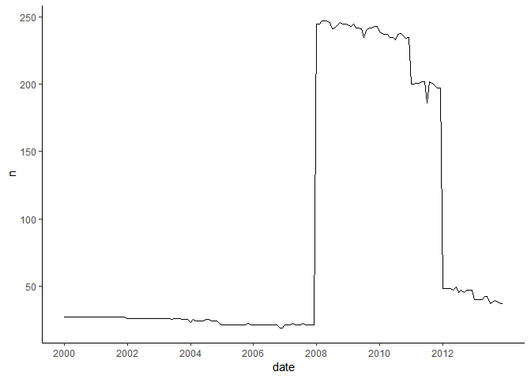

```r
# Unique newspapers
database %>% filter(!total == 0) %>% group_by(date) %>% distinct(paper) %>% count() %>%
  ggplot(aes(date, n)) +
  geom_line() +
  scale_x_date(breaks = as.Date(c("2000-01-01", "2002-01-01", "2004-01-01", "2006-01-01", "2008-01-01", "2010-01-01", "2012-01-01")), date_labels = "%Y") +
  theme_classic()
```

And how does the number of total monthly words develop?

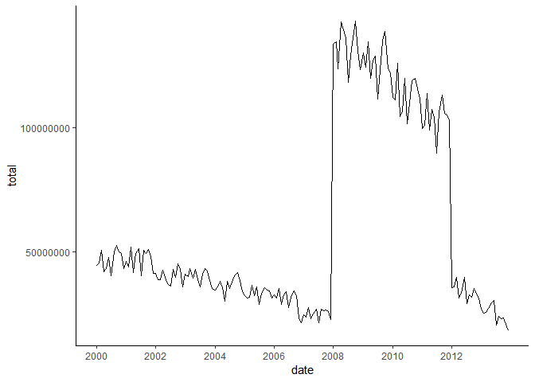

```r
# Total words
database %>% group_by(date) %>% summarise(total = sum(total)) %>%
  ggplot(aes(date, total)) +
  geom_line() +
  scale_x_date(breaks = as.Date(c("2000-01-01", "2002-01-01", "2004-01-01", "2006-01-01", "2008-01-01", "2010-01-01", "2012-01-01")), date_labels = "%Y") +
  theme_classic()
```

### Circulation data

Total circulation per year:

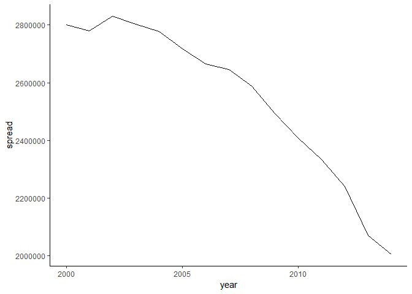

```r
coverage %>% group_by(year) %>% summarise(spread = sum(spread)) %>%
ggplot(aes(year, spread)) +
  geom_line() +
  theme_classic()
```

Number of unique newspapers per year.

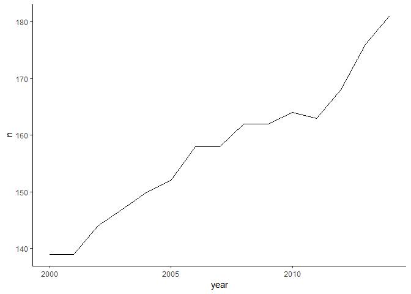

```r
coverage %>% group_by(year) %>% distinct(paper) %>% count() %>%
ggplot(aes(year, n)) +
  geom_line() +
  theme_classic()
```

## Match newspaper names using string distance

The newspaper names used in the two databases are often spelled a bit different. First I match the ones that have the excact same name. Then, I use several string distance measurements to match the rest. String distance metrics are ways to compare the similarity of two strings. They can for instance be the “minimum number of single-character edits needed to change one word into the other” (Levenshtein distance), or “1 minus the size of the intersection divided by the size of the union of the sample sets” (Jaccard distance). It is a bit messy, but it seems like the best way. Some newspapers also have to be manually matched at the end.

```r
# Match papers that have the exact same name.
papersCoverage <- data.frame(paper = tolower(unique(coverage$paper)), stringsAsFactors = FALSE)

papersDatabase <- data.frame(paper = unique(database$paper), stringsAsFactors = FALSE)

matchedPapers <- inner_join(papersCoverage, papersDatabase)
matchedPapers <- data.frame(s1name = matchedPapers$paper, s2name = matchedPapers$paper, stringsAsFactors = FALSE)

papersCoverage <- papersCoverage %>% filter(!paper %in% matchedPapers$s1name)
papersDatabase <- papersDatabase %>% filter(!paper %in% matchedPapers$s1name)

# Match using a variety of string distance measurements
emptyVector1 <- c(rep(0, length(papersDatabase$paper)))
paperNames <- data.frame(papersDatabase$paper, emptyVector1, stringsAsFactors = F)
names(paperNames) <- "name"

emptyVector2 <- c(rep(0, length(papersCoverage$paper)))
namesDekning <- data.frame(papersCoverage$paper, emptyVector2, stringsAsFactors = F)
names(namesDekning)[1] <- "name"

#distance.methods<-'jw'
distance.methods<-c('osa','lv','dl','lcs','qgram','cosine','jaccard','jw')
dist.methods<-list()
for (m in 1:length(distance.methods)) {
  dist.name.enh<-matrix(NA, ncol = length(paperNames$name), nrow = length(namesDekning$name))
  for (i in 1:length(paperNames$name)) {
    for (j in 1:length(namesDekning$name)) {
      dist.name.enh[j, i] <- stringdist(tolower(paperNames[i, ]$name),
                                        tolower(namesDekning[j, ]$name), method = distance.methods[m])
      #adist.enhance(paperNames[i,]$name,namesDekning[j,]$name)
    }
  }
  dist.methods[[distance.methods[m]]] <- dist.name.enh
}

match.s1.s2.enh <- NULL
for (m in 1:length(dist.methods)) {
  dist.matrix <- as.matrix(dist.methods[[distance.methods[m]]])
  min.name.enh <- apply(dist.matrix, 1, base::min)
  for (i in 1:nrow(dist.matrix)) {
    s2.i <- match(min.name.enh[i], dist.matrix[i, ])
    s1.i <- i
    match.s1.s2.enh <- rbind(data.frame(s2.i = s2.i, s1.i = s1.i, s2name = paperNames[s2.i, ]$name,
                                        s1name = namesDekning[s1.i, ]$name, adist = min.name.enh[i],
                                        method = distance.methods[m], stringsAsFactors = FALSE), match.s1.s2.enh)
  }
}

# Results from stringdist matching
matched.names.matrix <- dcast(match.s1.s2.enh, s2.i + s1.i + s2name + s1name ~ method, value.var = "adist")
matched.names.matrix <- matched.names.matrix %>% arrange(jw)

# Extract matches based on limiting values set for each string distance measure
matched2 <- matched.names.matrix %>%
  filter(jw <= 0.13 |
           jaccard <= 0.08 |
           cosine <= 0.072 |
           lcs <= 3 |
           dl <= 2 |
           lv <= 2 |
           osa <= 2) %>%
  select(s2name, s1name)

matchedPapers <- rbind(matchedPapers, matched2)

matched.names.matrix <- matched.names.matrix %>%
  filter(!s2name %in% matched2$s2name | !s1name %in% matched.names.matrix$s1name)

# Manually pick out the last matching papers.
matchedPapers <- rbind(matchedPapers, matched.names.matrix[c(1, 3, 5, 8, 11, 13, 76), c(3, 4)])
```

How many matching newspapers are there in the two databases?

```r
nrow(matchedPapers)
```

```
## [1] 178
```

Subset only the matched newspapers:

```r
coverage <- matchedPapers %>% rename(paper = s1name) %>% left_join(coverage) %>% select(-s2name)
database <- matchedPapers %>% rename(paper = s2name) %>% left_join(database) %>% select(-paper) %>% rename(paper = s1name)
```

### Add counties

```r
counties <- data.frame(county = c("Akershus", "Aust-Agder", "Buskerud", "Finnmark - Finnm?rku", "Hedmark", "Hordaland", "M?re og Romsdal", "Nordland", "Oppland",  "Oslo", "Rogaland", "Sogn og Fjordane", "Telemark", "Troms - Romsa", "Tr?ndelag", "Vest-Agder", "Vestfold", "?stfold", "Tr?ndelag", "Tr?ndelag"), from = c(0200, 0900, 0600, 2000, 0400, 1200, 1500, 1800, 0500, 0300, 1100, 1400, 0800, 1900, 5000, 1000, 700, 0100, 01600, 01700), stringsAsFactors = F)

coverage$municipality.no. <- as.numeric(coverage$municipality.no.)

coverageNumbers <- coverage %>% distinct(municipality.no.)

z <- character(nrow(coverageNumbers))

for (j in 1:nrow(coverageNumbers)){
   for (i in 1:nrow(counties)){
    if((coverageNumbers[j, 1] > counties[i, 2]) & (coverageNumbers[j, 1] < counties[i, 2] + 99)) {
    z[j] <- counties[i, 1]
    }
  }
}

coverageNumbers$county <- z

coverage <- inner_join(coverage, coverageNumbers, by = "municipality.no.")
```

### Tile graph

The tile graph shows whether there is data on the national library database for each newspaper in each month.

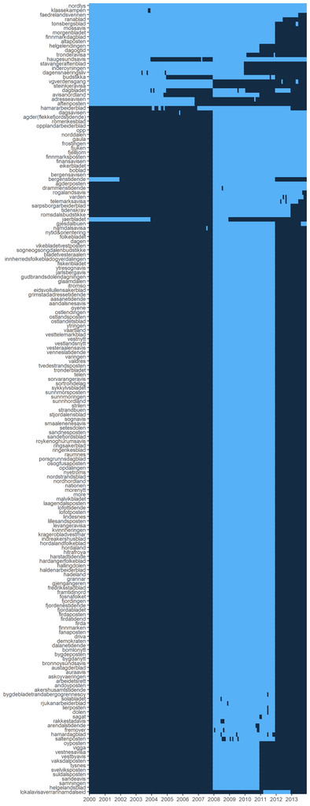

```r
possiblePapers <- tibble(paper = rep(rep(unique(database$paper)), each = 12*(noYears)),
                         date = rep(seq(from = as.Date("2000/1/1"), to = as.Date("2013/12/31"), by = "month"), length(unique(database$paper))))


papersPerMonth <- database %>%
  group_by(date, paper) %>%
  summarise(count = n()) %>%
  mutate(data = 1)

tileData <- right_join(papersPerMonth, possiblePapers)

tileData[is.na(tileData)] <- 0

tileData <- inner_join(tileData, papersPerMonth %>% group_by(paper) %>% summarise(noOfMonths = sum(data)) %>% ungroup())

tileData <- tileData %>% arrange(noOfMonths)

tileData$paper <- factor(tileData$paper, levels = (unique(tileData$paper)))

graphData <- tileData %>% #filter(year %in% 2000:2007) %>%
  ggplot(aes(date, paper)) +
  scale_y_discrete(expand=c(0,0)) +
  scale_x_date(expand = c(0,0), date_breaks = "1 year", date_labels = "%Y") +
  geom_tile(aes(fill = data, color = data), size = 1, show.legend = FALSE) +
  theme(axis.title.x=element_blank(),
        axis.title.y=element_blank())
```

We see that most of the newspapers only have data between the years 2008 and 2012. To get the most out of the dataset, I decide to create two individual sets of indexes: One for the years 2000:2007, and one for 2008:2011.

### Split the dataset:

I split the dataset in two, and use only newspapers that have at least 80% coverage in the selected time period.

```r
dataMonths2000 <- database %>%
  filter(year %in% 2000:2007) %>%
  distinct(paper, date) %>%
  group_by(paper) %>%
  count(name = "freq") %>%
  arrange(desc(freq)) %>%
  ungroup() %>%
  filter(freq * 100 / max(freq) > 80) # Select papers with < 20% missing data

dataMonths2008 <- database %>%
  filter(year %in% 2008:2011) %>%
  distinct(paper, date) %>%
  group_by(paper) %>%
  count(name = "freq") %>%
  arrange(desc(freq)) %>%
  ungroup() %>%
  filter(freq * 100 / max(freq) > 80) # Select papers with < 20% missing data

database <- rbind(database %>% filter(paper %in% unique(dataMonths2000$paper), year %in% 2000:2007),
                  database %>% filter(paper %in% unique(dataMonths2008$paper), year %in% 2008:2011))

database$index <- c(rep(2000, nrow(database[database$year %in% 2000:2007, ])),
                    rep(2008, nrow(database[database$year %in% 2008:2011, ])))
```

### Weights

Each newspaper gets a corresponding weight for each county/year pair.

I start by aggregating the circulation data for all the municipalities in each county.

```r
coveragePerYear <- coverage %>% group_by(paper, county, year) %>% summarise(spread = sum(spread)) %>% ungroup()
```

Some newspapers have missing data for some counties in some years. Because the sales number are relatively non-volative, I choose to interpolate by drawing a straight line between the closest year. For year at the end of the time series, i choose to set their value equal to the closest year available.

```r
paperNames <- unique(database$paper)

# Linear approximation of year/county pairs with missing data:
linApprox <- tibble(paper = rep(paperNames, each = 18*(2014-2000+1)),
                        county = rep(unique(coverage$county), each = (2014-2000+1), length(paperNames)),
                        year = rep(2000:2014, length(paperNames)*18))

coveragePerYear <- left_join(linApprox, coveragePerYear)

coveragePerYear <- coveragePerYear %>% arrange(paper, county, year)

coveragePerYear <- coveragePerYear %>% group_by(paper, county) %>% mutate(spread = na.approx(spread, na.rm = FALSE, rule = 2)) %>% ungroup() # For each group, NAs at the left or right side are set equal to the closest year.
```

THe weights are calcutated as the ratio of newspapers sold to all newspapers sold, for each county, in each year. The weights therefore sum to one for each county/year pair.

```r
# Add rows with sum of spread in all counties
totalCoveragePerYear <- coveragePerYear %>% group_by(year, paper) %>% summarise(spread = sum(spread, na.rm = TRUE)) %>% ungroup()

totalCoveragePerYear$county <- "Total"

coveragePerYear <- rbind(coveragePerYear, totalCoveragePerYear)

# Add column with total yearly coverage per county
coveragePerYear <- inner_join(
  coveragePerYear,
  coveragePerYear %>% group_by(year, county) %>% summarise(totCoverage = sum(spread, na.rm = TRUE)) %>% ungroup())

# Calculate weights
coveragePerYear$weigth <- coveragePerYear$spread / coveragePerYear$totCoverage
```

## Uncertainty index

We start by joining the circulation data with the library data.

```r
database <- inner_join(database, coveragePerYear)
```

Divide the number of uncertainty words by the total number of words to get **uncertainty per word**. I do this to control for the change in total number of words over time. Next, I multiply these numbers with the corresponding weights that we created, to get **uncertainty per word per newspaper sold, per newspaper**.

```r
database$uncertaintyPerWord <- database$uncertainty / database$total

# Standarize each weighted newspaper-level series to unit standard deviation
database <- database %>% group_by(paper, county, index) %>% mutate(stdr = sd(uncertaintyPerWord, na.rm = T)) %>% ungroup()

database <- database %>% group_by(paper, county, index) %>% mutate(uncertaintySt = uncertaintyPerWord / stdr) %>% ungroup() #Uncertainty per word divided by sd

database$uncertaintyWeighted <- database$uncertaintyPerWord * database$weigth # Uncertainty per word per newspaper sold, per newspaper.

database$uncertaintyStWeighted <- database$uncertaintySt * database$weigth
```

Then its time to aggregate all the newspapers together.

```r
# Make collumns with average and sum of all the newspapers by month
database <- database %>%
  group_by(county, date, index) %>%
  summarise(totalSum = sum(total, na.rm = T), # Total words per month
            usikkerhetSum = sum(uncertainty, na.rm = T), # Number of uncertainty words per month
            uncertaintyPerWordSum = sum(uncertaintyPerWord, na.rm = T), # Number of uncertainty words per word per month
            uncertaintyWeightedSum = sum(uncertaintyWeighted, na.rm = T), # Uncertainty per paper, per month
            total = mean(total, na.rm = T), # Mean words per newspaper per month
            usikkerhet = mean(uncertainty, na.rm = T), # Mean uncertainty words per newspaper per month
            uncertaintyPerWord = mean(uncertaintyPerWord, na.rm = T), # Mean uncertainty words per word, per newspaper per              month
            uncertaintyStWeighted = mean(uncertaintyStWeighted, na.rm = T),
            uncertaintyWeighted = mean(uncertaintyWeighted, na.rm = T)) %>% ungroup() # Mean uncertainty per paper, per paper, per month
```

After aggregating the newspaper series I normalize each county index to mean 100 to make it easier to interpret.

```r
# Normalize to mean 100 for St
seriesMeanSt <- database %>% group_by(county, index) %>% summarise(mean(uncertaintyStWeighted, na.rm = T)) %>% ungroup()

database <- inner_join(database, seriesMeanSt)

database$uncertaintyNormSt <- database$uncertaintyStWeighted * (100/database$`mean(uncertaintyStWeighted, na.rm = T)`)


# Normalize to mean 100
seriesMean <- database %>% group_by(county, index) %>% summarise(mean(uncertaintyWeighted, na.rm = T)) %>% ungroup()

database <- inner_join(database, seriesMean)

database$uncertaintyNorm <- database$uncertaintyWeighted * (100/database$`mean(uncertaintyWeighted, na.rm = T)`)
```

I also make 10 month rolling averages of the uncertainty indexes.

```r
# Rolling mean
database <-
  database %>%
  group_by(county, index) %>%
  mutate(rollingMeanSt = c(rep(NA, 9), rollmean(uncertaintyNormSt, 10, align = "right")),
         rollingMean = c(rep(NA, 9), rollmean(uncertaintyNorm, 10, align = "right"))) %>% ungroup()
```

### Economic variables

I collect a number of economic variables for comparison by using a number of different APIs. The variables are: * Brent crude oil price the U.S. Energy Information Administration * Local unemployment numbers from statistics Norway * Local migration numbers from statistics Norway * A list of uncertainty events from the Vegard Larsen paper [Components of uncertainty](https://ideas.repec.org/p/bny/wpaper/0053.html) 2017. I also added the 2011 Norway terror attack to the list. * The [World Uncertainty Index](http://www.policyuncertainty.com/wui_quarterly.html) for Norway

```r
# Brent crude spot price from the U.S. Energy Information Administration API
oilPrice <- GET("http://api.eia.gov/series/?api_key=0d61de68602f55c38b02f207c5896434&series_id=PET.RBRTE.D")
oilPrice <- fromJSON((rawToChar(oilPrice$content)))
oilPrice <- as_tibble(oilPrice$series$data[[1]])
names(oilPrice) <- c("date", "oilPrice")
oilPrice$date <- as.Date(oilPrice$date, format = "%Y%m%d")
oilPrice$oilPrice <- as.numeric(oilPrice$oilPrice)

# Norwegian local unemployment from Statistics Norway API
queryUnemployment <-
  pxweb_query(list(
    "Region" = c("*"), # Use "*" to select all
    "Kjonn" = c("0"), # 0 = both
    "ContentsCode" = c("Registrerte1"),
    "Tid" = c("*")))

unemployment <- pxweb_get("https://data.ssb.no/api/v0/en/table/10594", queryUnemployment)
unemployment <- as.data.frame(unemployment, column.name.type = "text", variable.value.type = "text", stringsAsFactors = FALSE)
unemployment <- unemployment %>% filter(region %in% c(unique(counties[[1]])))
unemployment <- unemployment %>%
  inner_join(tibble(date = rep(seq(from = as.Date("1990/1/1"), to = as.Date("2014/12/31"), by = "month")),
                    month = paste0(rep(1990:2014, each = 12),
                                   "M",
                                   rep(sprintf("%02d", 1:12), 2014-1990+1)))) %>% select(-month, -sex)
names(unemployment) <- c("county", "unemployed", "date")

# Migration withing Norway from Statistics Norway API
queryMigration <-
  pxweb_query(list(
    "Region" = c("*"),
    "ContentsCode" = c("Netto"),
    "Tid" = c("*")
  ))

migration <- pxweb_get("https://data.ssb.no/api/v0/en/table/05471", queryMigration)
migration <- as.data.frame(migration, column.name.type = "text", variable.value.type = "text", stringsAsFactors = FALSE)
migration <- migration %>% filter(region %in% c(unique(counties[[1]])))

# World uncertainty index by Ahir, Bloom and Furceri:
tempWU = tempfile(fileext = ".xlsx")
download.file("http://www.policyuncertainty.com/media/WUI_Data.xlsx", destfile = tempWU, mode = 'wb')
worldUncertainty <- readxl::read_xlsx(tempWU, sheet = 3)
worldUncertainty <- worldUncertainty %>% select(year, NOR) %>% filter(substr(year, 1, 4) %in% 1996:2014) %>% select(-year)
worldUncertainty$date <- seq(from = as.Date("1996/1/1"), to = as.Date("2014/12/31"), by = "quarter")

saveRDS(oilPrice, "Data/oilPrice.rds")
saveRDS(unemployment, "Data/unemployment.rds")
saveRDS(migration, "Data/migration.rds")
saveRDS(worldUncertainty, "Data/worldUncertainty.rds")
```

At last, I add the economic variables to final database

```r
oilPrice <- readRDS("Data/oilPrice.rds")
unemployment <- readRDS("Data/unemployment.rds")
migration <- readRDS("Data/migration.rds")
worldUncertainty <- readRDS("Data/worldUncertainty.rds")

# List of historical uncertainty events from Larsen paper.
uncertaintyEvents <- read.csv("Data/uncertaintyEvents.csv", sep = ";", stringsAsFactors = F)
uncertaintyEvents$date <- as.Date(uncertaintyEvents$date, format = "%d.%m.%Y")

# Create series with oil price from 2000 to 2013
prove <- left_join(database, oilPrice)

# Create series with unemployemt for each county from 2000 to 2013
database <- left_join(database, unemployment[, c("date", "county", "unemployed")])

Skaler <- function(x, y){
((x - min(x)) / (max(x) - min(x))) * (max(y) - min(y)) + min(y)
}

for (i in seq_along(unique(database$county))) {
  database[database$county == unique(database$county)[i], "unempScaler"] <- Skaler(database[database$county == unique(database$county)[i], "unemployed", ], database[database$county == unique(database$county)[i], "uncertaintyNorm"])
}

database <- left_join(database, worldUncertainty)
database$NOR <- rep(database[!is.na(database$NOR),][["NOR"]], each = 3)

for (i in seq_along(unique(database$county))) {
  database[database$county == unique(database$county)[i], "NORScaler"] <- Skaler(database[database$county == unique(database$county)[i], "NOR", ],
database[database$county == unique(database$county)[i], "uncertaintyNorm"])
}

#database[,"worldIndex"] <-  Skaler(database$worldIndex, database$uncertaintyNorm)

# Create series with migration for each county from 2000 to 2013
#database <- left_join(database, migration)
```

### Graphs

National uncertianty index 2000:2007

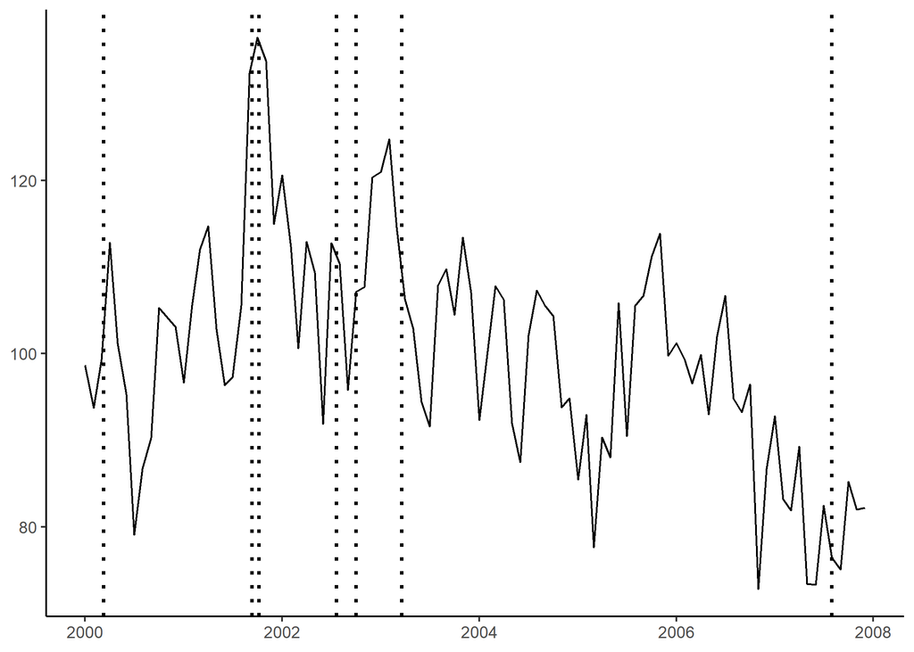

```r
database %>% filter(index == 2000, county == "Total") %>%
  ggplot(aes(date, uncertaintyNorm)) +
  geom_line() +
  #geom_line(aes(dateMonth, rollingMean)) +
  #geom_line(aes(dateMonth, rollingMean)) +
  geom_vline(xintercept = uncertaintyEvents[c(12, 14, 15, 16, 17, 18, 19), 2],
             show.legend = T, linetype = "dotted", size = 1) +
  theme_classic() +
  theme(axis.title = element_blank())
```

National uncertianty index 2008:2011

Uncertainty events from left to right: Collapse of Lehman Brothers, first Libyan civil war, Norway attacks, Greek proposed economy referendum.

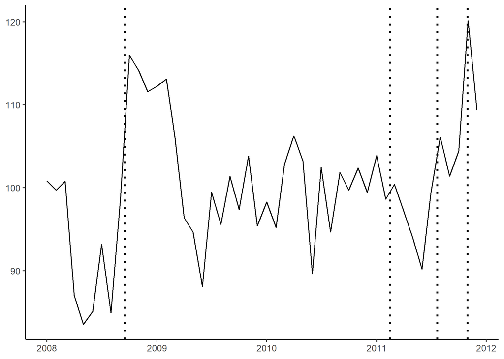

```r
database %>% filter(index == 2008, county == "Total") %>%
  ggplot(aes(date, uncertaintyNorm)) +
  geom_line() +
 # geom_line(aes(dateMonth, worldIndex)) +
  geom_vline(xintercept = uncertaintyEvents[c(20, 21, 23, 25), 2],
             show.legend = T, linetype = "dotted", size = 1) +
  theme_classic() +
  theme(axis.title = element_blank())
```

Local uncertianty index 2000:2007

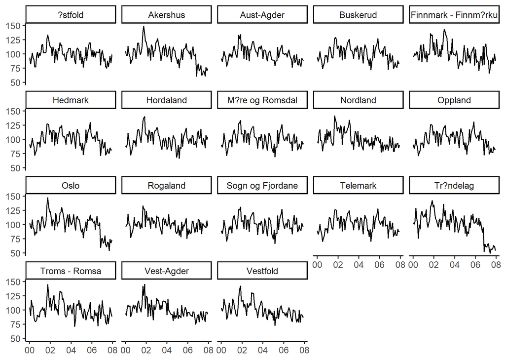

```r
database %>% filter(index == 2000, !county == "Total") %>%
  ggplot(aes(x = date, y = uncertaintyNorm)) +
  geom_line() +
  facet_wrap(~county) +
  theme_classic() +
  theme(legend.position = "none") +
  scale_x_date(as.Date(c("2008-01-01","2009-01-01", "2010-01-01", "2011-01-01", "2012-01-01")), date_labels = "%y") +
  theme(axis.title = element_blank())
```

Local uncertianty index 2008:2011

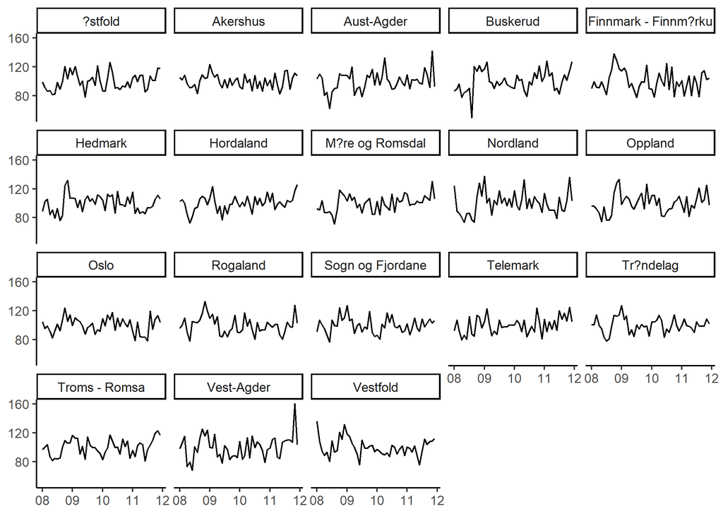

```r
database %>% filter(index == 2008, !county == "Total") %>%
  ggplot(aes(x = date, y = uncertaintyNorm)) +
  geom_line() +
  facet_wrap(~county) +
  theme_classic() +
  theme(legend.position = "none") +
  scale_x_date(as.Date(c("2008-01-01","2009-01-01", "2010-01-01", "2011-01-01", "2012-01-01")), date_labels = "%y") +
  theme(axis.title = element_blank())
```

## Comparison to the world uncertainty index for Norway:

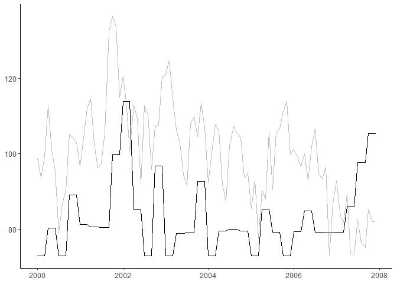

```r
database %>% filter(index == 2000, county == "Total") %>%
  ggplot(aes(date, uncertaintyNorm)) +
  geom_line(color = "gray") +
  geom_line(aes(date, NORScaler)) +
  theme_classic() +
  theme(axis.title = element_blank())
```

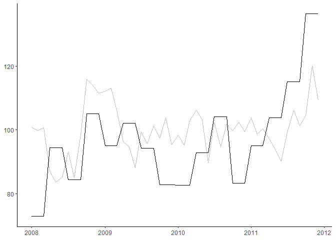

```r
database %>% filter(index == 2008, county == "Total") %>%
  ggplot(aes(date, uncertaintyNorm)) +
  geom_line(color = "gray") +
  geom_line(aes(date, NORScaler)) +
  theme_classic() +
  theme(axis.title = element_blank())
```